# FINAL_PART1

Neemias Moreira

2023-12-07

##### This the final project Part-1, Clustering:

### Goal: Analyze the structure of the Avian Measurements data set.

### First let’s do a exploratory analisys on the data set.

```r
str(AvianM)
```

```
## 'data.frame':    344 obs. of  5 variables:
##  $ X                : int  1 2 3 4 5 6 7 8 9 10 ...
##  $ bill_length_mm   : num  39.1 39.5 40.3 NA 36.7 39.3 38.9 39.2 34.1 42 ...
##  $ bill_depth_mm    : num  18.7 17.4 18 NA 19.3 20.6 17.8 19.6 18.1 20.2 ...
##  $ flipper_length_mm: int  181 186 195 NA 193 190 181 195 193 190 ...
##  $ body_mass_g      : int  3750 3800 3250 NA 3450 3650 3625 4675 3475 4250 ...
```

```r
head(AvianM)
```

```
##   X bill_length_mm bill_depth_mm flipper_length_mm body_mass_g
## 1 1           39.1          18.7               181        3750
## 2 2           39.5          17.4               186        3800
## 3 3           40.3          18.0               195        3250
## 4 4             NA            NA                NA          NA
## 5 5           36.7          19.3               193        3450
## 6 6           39.3          20.6               190        3650
```

```r
tail(AvianM)
```

```
##       X bill_length_mm bill_depth_mm flipper_length_mm body_mass_g
## 339 339           45.7          17.0               195        3650
## 340 340           55.8          19.8               207        4000
## 341 341           43.5          18.1               202        3400
## 342 342           49.6          18.2               193        3775
## 343 343           50.8          19.0               210        4100
## 344 344           50.2          18.7               198        3775
```

```r
any(is.na(AvianM))
```

```
## [1] TRUE
```

```r
na_count <- sum(is.na(AvianM))
cat("Number of NA values in the dataset:", na_count, "\n")
```

```
## Number of NA values in the dataset: 8
```

As we have some NA values on the data set let’s do a cleaning on those rows.

```r
AvianM1 <- na.omit(AvianM)
any(is.na(AvianM1))
```

```
## [1] FALSE
```

## Now let’s start the K-Means clustering to group the Avian Measurements dataset.

Let’s start the data exploratory with the heat map of the data set:

```
##     43  20  24  21
## 43 0.0 2.8 1.2 1.0
## 20 2.8 0.0 2.3 2.8
## 24 1.2 2.3 0.0 1.0
## 21 1.0 2.8 1.0 0.0
```

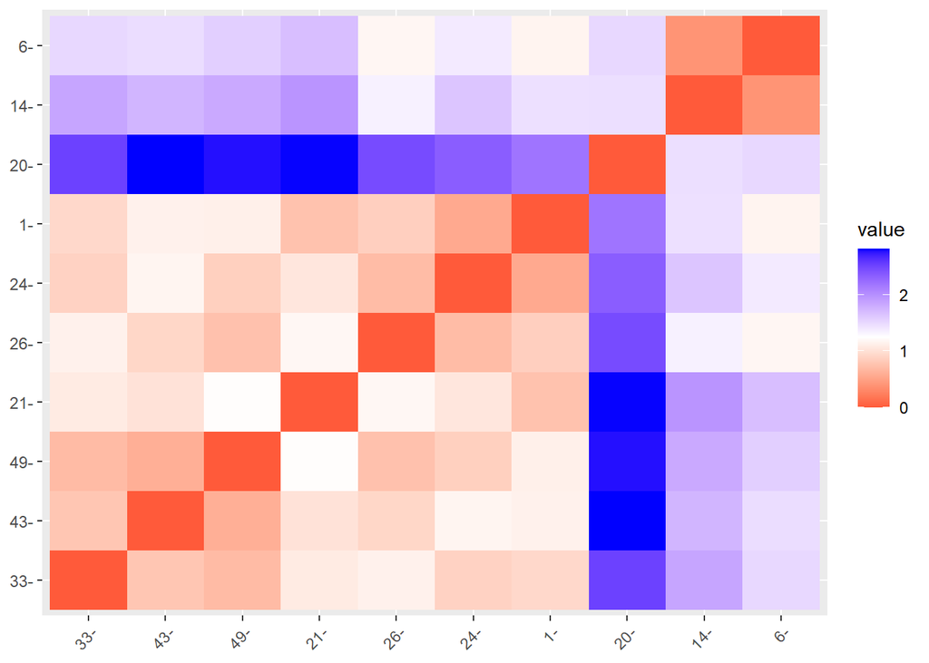

Using the elbow plot to determine the best value of k using an elbow plot:

```r
wss <- sapply(1:df1, function(k){kmeans(AvianM1, k, nstart=20, iter.max=15)$tot.withinss})
```

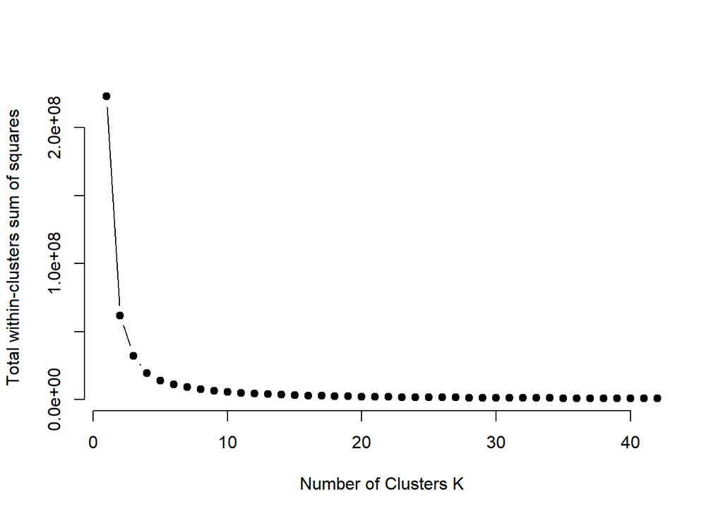

```r
plot(1:df1, wss, type="b", pch =19, frame=FALSE, xlab="Number of Clusters K", ylab="Total within-clusters sum of squares")
```

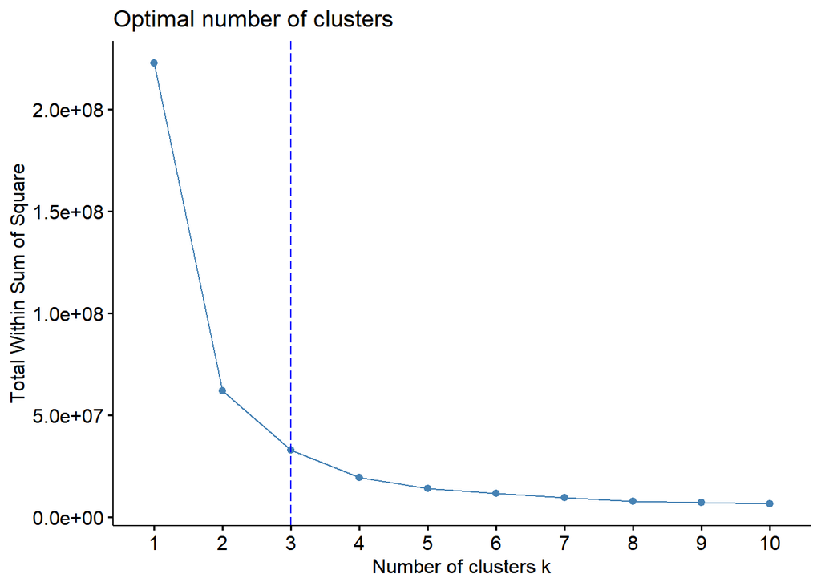

```r
fviz_nbclust(AvianM1, kmeans, method="wss") + geom_vline(xintercept =3, linetype= 5, col= "blue")
```

Testing with 3 clusters:

```r
km.res_final_3 <- kmeans(dfAvianM, 3, nstart = 25)
km.res_final_3$totss
```

```
## [1] 1705
```

```r
km.res_final_3$betweenss
```

```
## [1] 1260.203
```

```r
km.res_final_3$betweenss/km.res_final_3$totss
```

```
## [1] 0.7391218
```

Those are the values about the Totss with Betweenss, the meaning of this value is to show about, the percentage of variation explained by clustering is frequently calculated using these two metrics, and this information can be helpful in assessing how well the clustering solution fits the data.

In this case the value is 0.739, where show us a good correlation with 3 clusters.

To a better understanding of the data set, let’s plot some visualization:

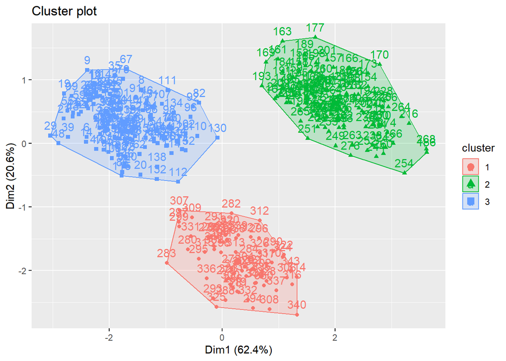

Now another visualization:

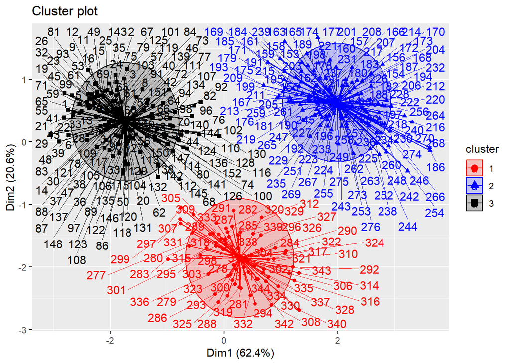

Now, Mean, Median and Standard Variation:

```r
aggregate(AvianM1, by=list(cluster=avian_menber_3$cluster), mean)
```

```
##   cluster         X bill_length_mm bill_depth_mm flipper_length_mm body_mass_g
## 1       1 310.50000       48.83382      18.42059          195.8235    3733.088
## 2       2 214.03252       47.50488      14.98211          217.1870    5076.016
## 3       3  76.98013       38.79139      18.34636          189.9536    3700.662
```

```r
aggregate(AvianM1, by=list(cluster=avian_menber_3$cluster), median)
```

```
##   cluster     X bill_length_mm bill_depth_mm flipper_length_mm body_mass_g
## 1       1 310.5          49.55         18.45               196        3700
## 2       2 214.0          47.30         15.00               216        5000
## 3       3  77.0          38.80         18.40               190        3700
```

```r
aggregate(AvianM1, by=list(cluster=avian_menber_3$cluster), sd)
```

```
##   cluster        X bill_length_mm bill_depth_mm flipper_length_mm body_mass_g
## 1       1 19.77372       3.339256     1.1353951          7.131894    384.3351
## 2       2 35.70621       3.081857     0.9812198          6.484976    504.1162
## 3       3 43.76810       2.663405     1.2166498          6.539457    458.5661
```

To summarize, the standard deviation quantifies the range of values surrounding the mean, the mean provides an average number, and the median provides a center value. When combined, these metrics provide a thorough grasp of the variability and central tendency of a dataset.

# Now let’s try with another value of K-4 Clusters:

```
## [1] 1705
```

```
## [1] 1339.063
```

```
## [1] 0.7853743
```

In this case the value is 0.785, a small improvement on the ratio.

However, let’s visualization those clusters:

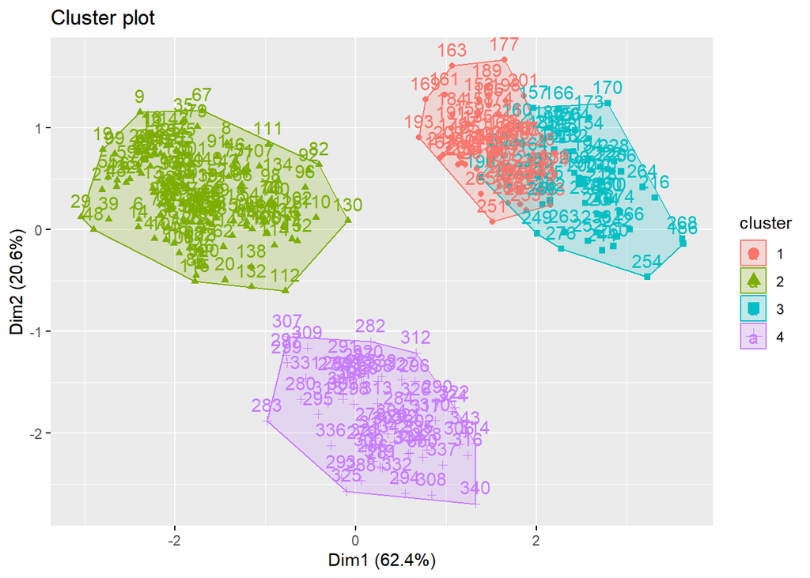

One more visualization:

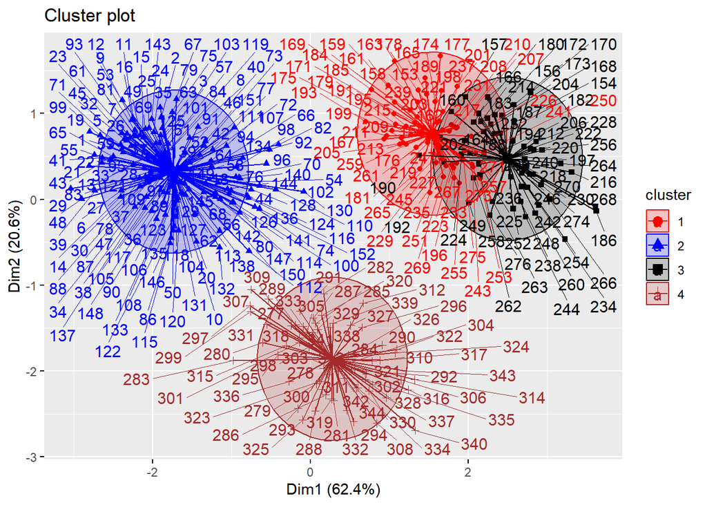

As we can see with 4 clusters with have overlap of clusters what is not interest to further analysis.

With K-3 clusters has the best distribution.

## Now using Hierarchical clustering to group the Avian Measurements data set.

# Dendrogram using AGNES:

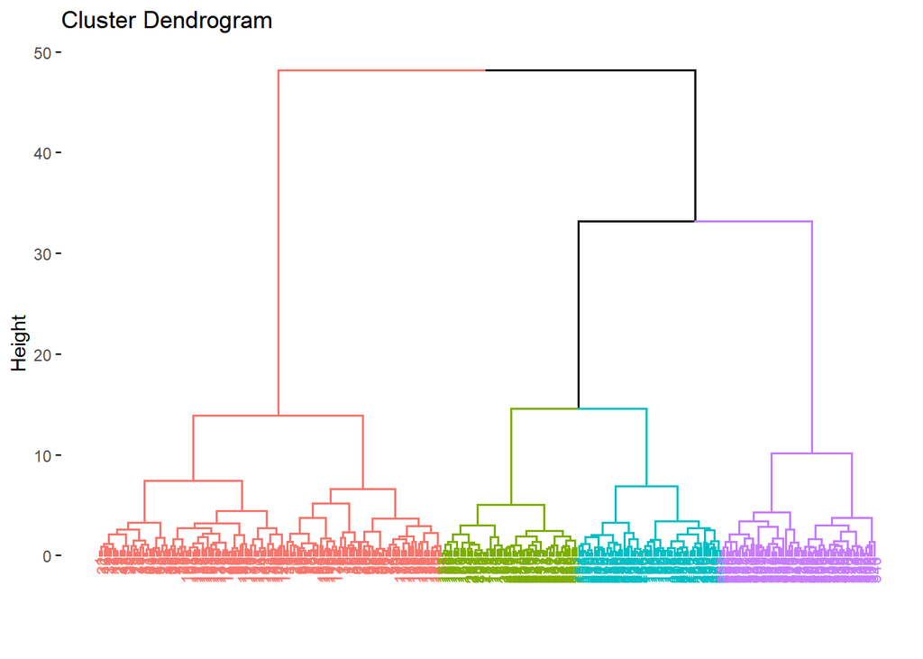

# Cophenetic correlation value:

```
##          [,1]     [,2]
## [1,] 1.000000 0.975417
## [2,] 0.975417 1.000000
```

```
## [1] 0.975417
```

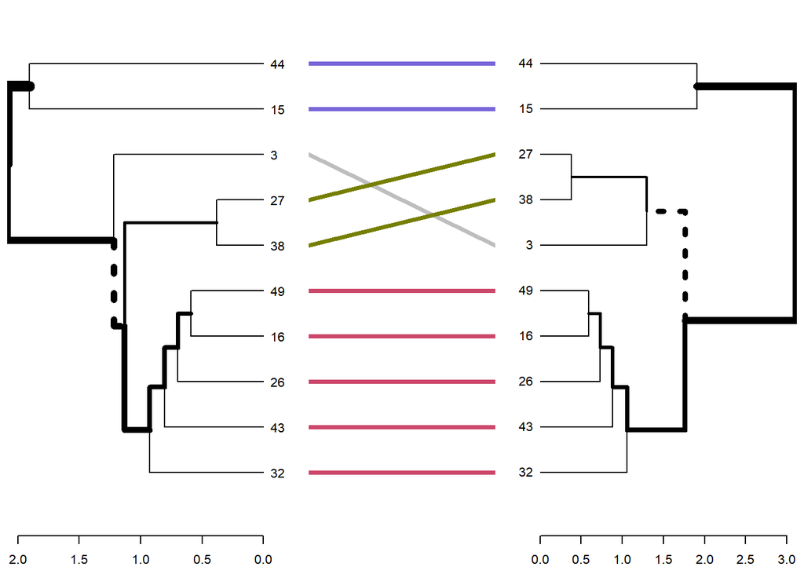

```
## [1] 0.03838376
```

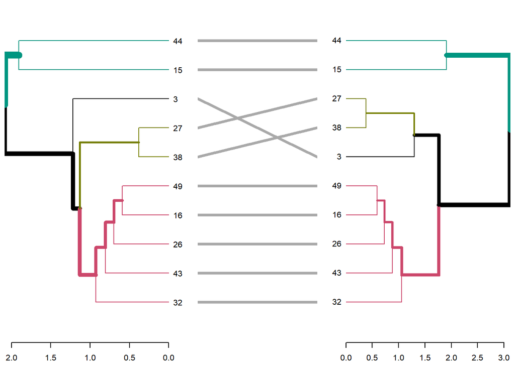

## A visualization with color with AGNES method k clusters:

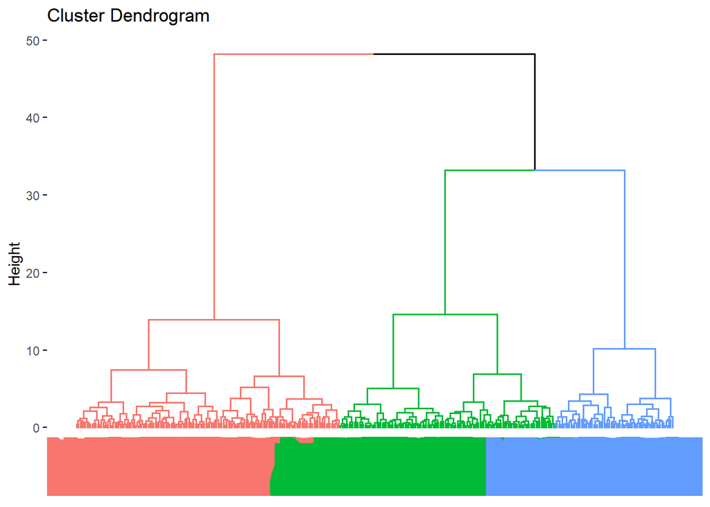

## Dendrogram using DIANA:

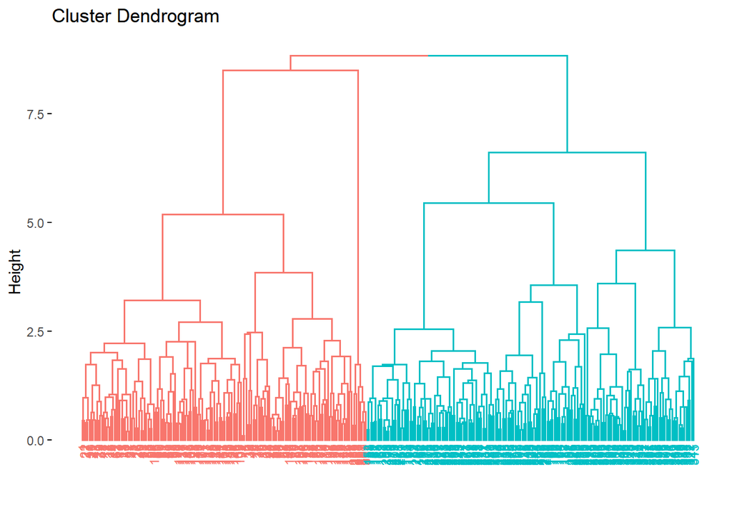

## To sum up:

In the comprehensive exploration of the Avian Data Set, various methodologies have been employed, each offering distinct approaches that contribute valuable insights to the dataset’s intricate patterns. It is evident that a deeper analysis of this dataset holds great promise.

In my perspective, the most effective means of determining the optimal number of clusters (k) is through the utilization of an elbow plot. This graphical representation not only aids in identifying the elbow point but also highlights the significance of selecting an appropriate value for k in the K-means clustering algorithm. Notably, the elbow plot analysis suggests that the most advantageous configuration for k is three in the context of the Avian Data Set.

The choice of three clusters not only aligns with the elbow plot’s recommendation but also yields meaningful results. Employing the K-means algorithm with k set to 3 generates clusters that encapsulate substantial insights within the dataset. Furthermore, this approach enhances the interpretability of the results and facilitates a more intuitive understanding of the underlying patterns.

In conclusion, the amalgamation of diverse methodologies and the adoption of the elbow plot for determining k collectively strengthen the foundation for a comprehensive analysis of the Avian Data Set. The strategic choice of three clusters, supported by the elbow plot, not only optimizes the K-means algorithm but also enriches the overall understanding of the dataset’s intricacies, setting the stage for further exploration and insights.